# Final Project

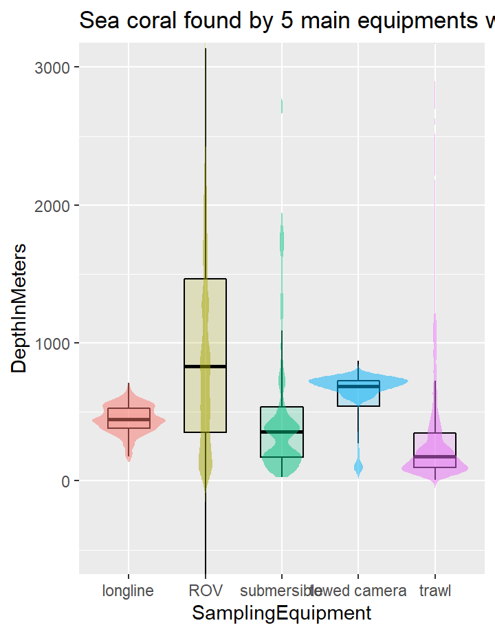

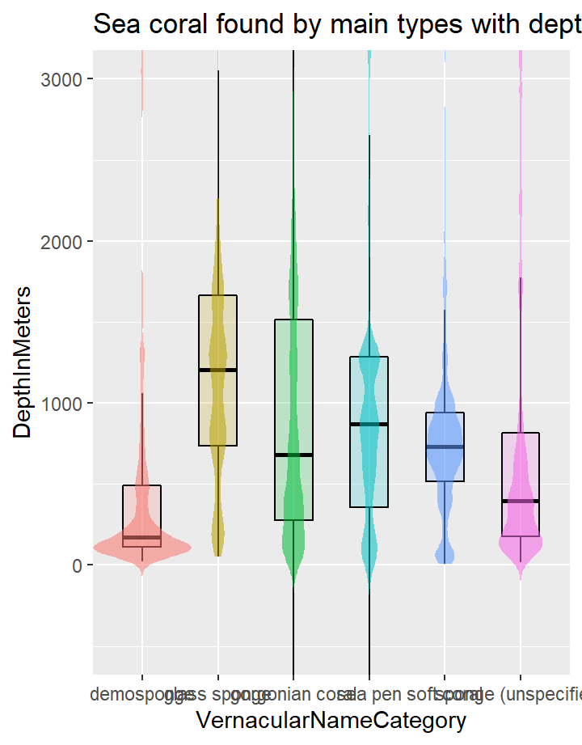

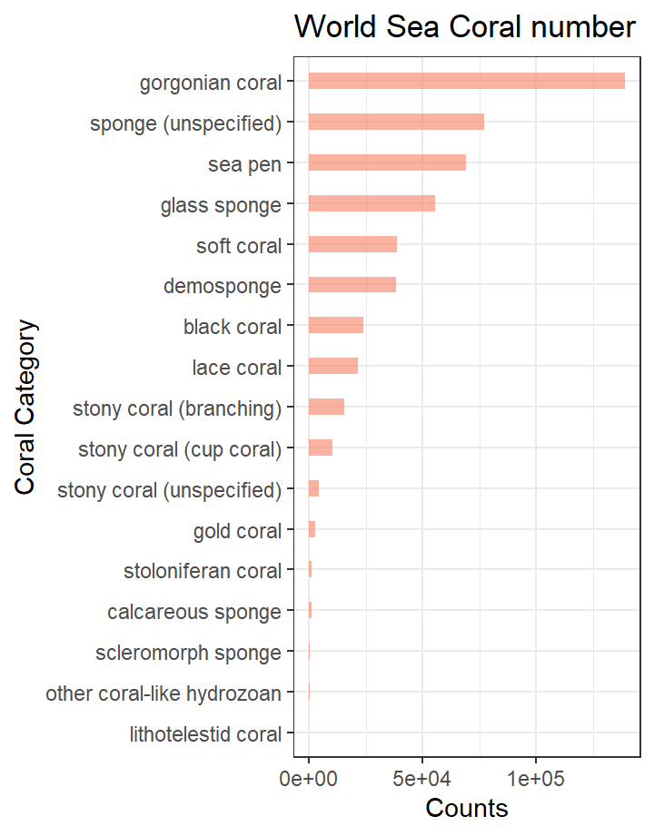

[figure not shown]

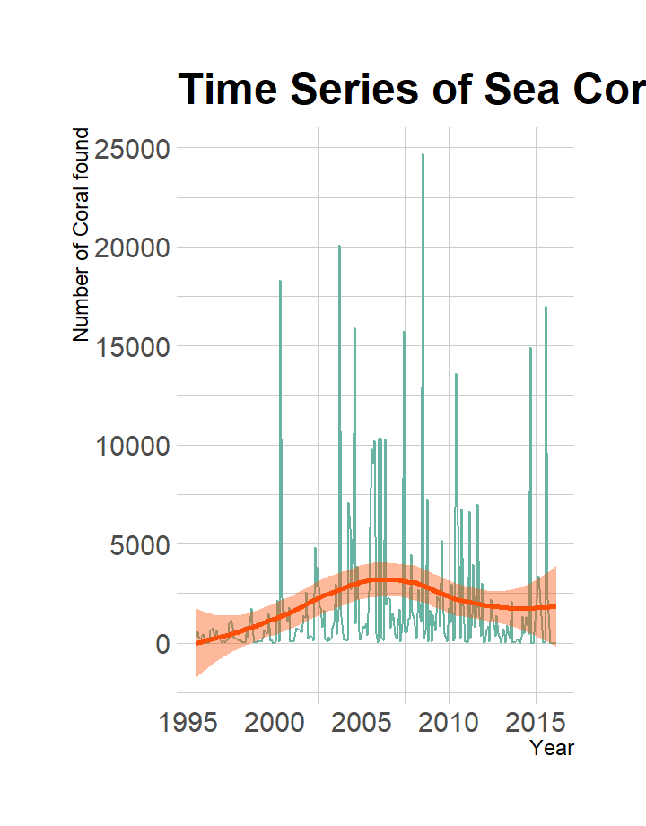

# About

The data is downloaded from Kaggle.com.

https://www.kaggle.com/noaa/deep-sea-corals

This dataset contains information about deep sea corals and sponges collected by NOAA and NOAA’s partners.Amongst the data are geo locations of deep sea corals and sponges and the whole thing is tailored to the occurrences of azooxanthellates - a subset of all corals and all sponge species (i.e. they don’t have symbiotic relationships with certain microbes). Additionally, these records only consists of observations deeper than 50 meters to truly focus on the deep sea corals and sponges.

# EDA

- To find the woking range of each equipments, a plot of five main equipments respect to the depth of water of coral found is made.
- From the plot, it is clearly that most corals are found between 0m - 1000m.
- Among all devices, the ROV has the widest range of finding corals.
- Besides, most corals found in deep sea are detected by the ROV.

### Sea coral found by 5 main equipments with depth

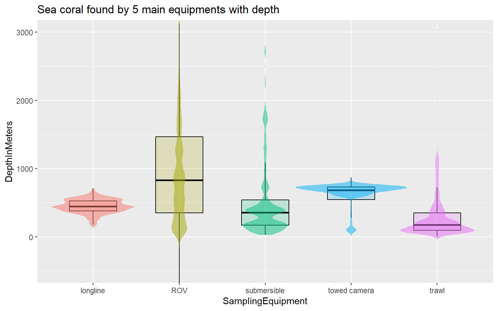

- The plot below shows the depth of main categories of corals founded.
- From the plot, we can find that eccept demosponge which are found near sea level, all other are mainly found between 400m- 1500m.
- The gorgonian coral has the widedst range of distribution while the demosponge has the shortest.

### Sea coral found by main types with depth

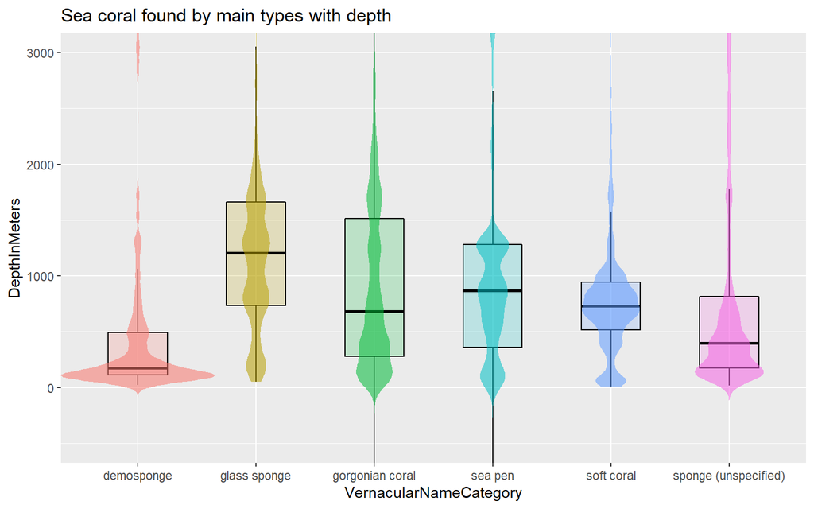

- Plot below shows the founded number of each corals.
- The gorgonian coral has the largest number among all corals.
- Most corals are gorgonian coral,sponge (unspecified),sea pen,glass sponge, soft coral and demosponge, and some of them are showed in previous image.

### World Sea Coral number

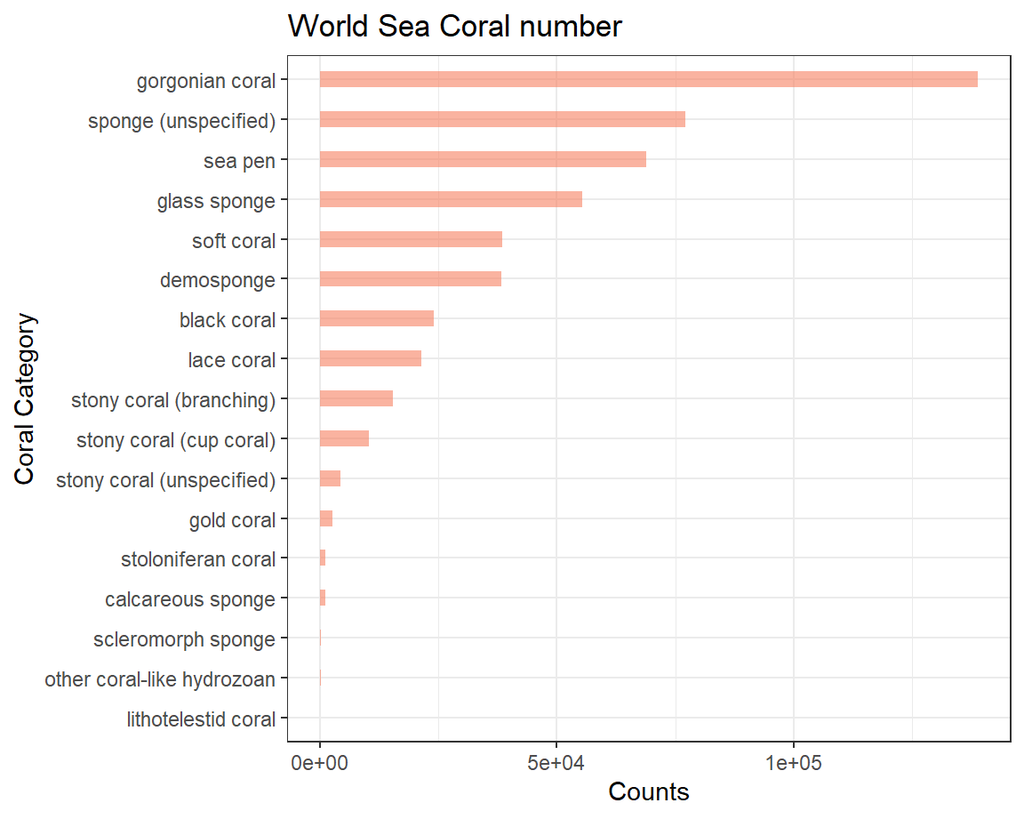

# Sea Coral Map

- The plot is a world map of position of main coral categories.
- Most corals are found near the coast espacially the West and East coast of North Amarican.
- Few corals are found Indian Ocean.
- The coast of Alaska contains huge amount of the different corals espacially the soft corals.
- Gorgonian coral which is the greatest in number has the most diverse distribution arong all the world.

## Geo plot of different sea coral

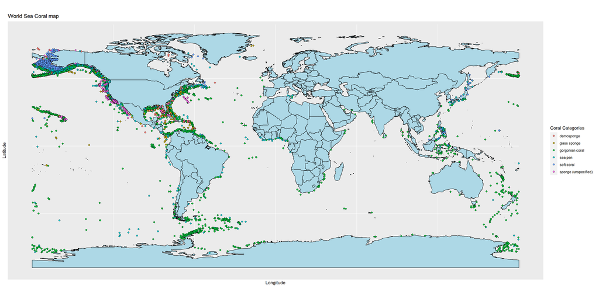

# Sankey plot (network)

- The plot is an sankey network bwteen categoral of corals and the depth of where they were found.
- The plot can be draged or clicked by mouse.
- Most corals are detected between 0m - 400m below the sea level.
- Only few corals are found below 2,000m

## Main depth of five main sea corals found

# Main depth of five main sea corals found

[interactive chart not shown]

# Time Series

[figure not shown]

# Word Cloud

- The plot is a word cloud shows the repository of corals.(Refresh may be needed)
- Suprisingly, the most common word is “research” which is an academic word.
- From the word cloud, we can see that most corals are found by those research team, institude and universities.
- Besides, finding a new sea corals depends more on science rather than economy or business.

## Word Cloud

[interactive chart not shown]